# Introduction

## Checkout df

```python
# rename to df
df = shorod
```

```python
# sort by date
df = df.sort_values('OrderDate')
```

```python
# All ID variables can be dropped
# except EmployeeID and SupplierID and ShipperID
# because they do not have a lookup table
cols_ID = ['CustomerID', 'ProductID', 'CategoryID', 'DivisionID']
df.drop(cols_ID, inplace=True, axis=1)
```

```python
# sort by date
df = df.sort_values('OrderDate')
```

```python
# CategoryName is suffient, the description of the category is not needed
df.drop(['Description'], inplace=True, axis=1)
```

```python
df.columns
```

```
Index(['OrderID', 'LineNo', 'ShipperID', 'EmployeeID', 'ShipmentDate',
       'OrderDate', 'Freight', 'Quantity', 'UnitPrice', 'Discount',
       'ShipperIDorName', 'ProductName', 'SupplierID', 'QuantityPerUnit',
       'UnitCost', 'UnitsInStock', 'UnitsOnOrder', 'CustomerName', 'City',
       'Country', 'DivisionName', 'CategoryName'],
      dtype='object')
```

```python
df.shape
```

```
(17032, 22)
```

```python
n = df.shape[0]
```

```python
# zero NA
assert df.isnull().sum().sum() == 0
```

```python
# first row
df.loc[0, :]
```

```
OrderID                            10248
LineNo                                 1
ShipperID                              2
EmployeeID                             2
ShipmentDate         2014-07-17 00:00:00
OrderDate            2014-06-29 00:00:00
Freight                            43.48
Quantity                              10
UnitPrice                          14.04
Discount                               0
ShipperIDorName    World Wide Transports
ProductName                Walking Shoes
SupplierID                            20
QuantityPerUnit                        1
UnitCost                           10.95
UnitsInStock                          26
UnitsOnOrder                           0
CustomerName            Dr Jims Trousers
City                              London
Country                               UK
DivisionName                      Europe
CategoryName            Women's Footwear
Name: 0, dtype: object
```

```python
df.describe()
```

|  | OrderID | LineNo | ShipperID | EmployeeID | Freight | Quantity | UnitPrice | Discount | SupplierID | QuantityPerUnit | UnitCost | UnitsInStock | UnitsOnOrder |
| --- | --- | --- | --- | --- | --- | --- | --- | --- | --- | --- | --- | --- | --- |
| count | 17032.000000 | 17032.000000 | 17032.000000 | 17032.000000 | 17032.000000 | 17032.000000 | 17032.000000 | 17032.000000 | 17032.000000 | 17032.000000 | 17032.000000 | 17032.000000 | 17032.000000 |
| mean | 13553.927078 | 2.107327 | 2.878112 | 4.950446 | 50.353610 | 24.936414 | 33.691178 | 0.055743 | 14.489373 | 23.679427 | 26.448995 | 39.760979 | 8.120597 |
| std | 1923.020984 | 1.550054 | 1.383721 | 2.865778 | 17.580939 | 20.186763 | 57.047959 | 0.083121 | 8.220952 | 28.540486 | 42.372797 | 36.060250 | 19.790074 |
| min | 10248.000000 | 1.000000 | 1.000000 | 1.000000 | 11.422512 | 1.000000 | 0.865024 | 0.000000 | 1.000000 | 1.000000 | 0.890000 | 0.000000 | 0.000000 |
| 25% | 11896.000000 | 1.000000 | 2.000000 | 3.000000 | 34.794019 | 11.000000 | 9.641237 | 0.000000 | 7.000000 | 1.000000 | 7.400000 | 17.000000 | 0.000000 |
| 50% | 13563.000000 | 2.000000 | 3.000000 | 5.000000 | 50.043621 | 20.000000 | 20.710736 | 0.000000 | 14.000000 | 15.000000 | 16.170000 | 25.000000 | 0.000000 |
| 75% | 15226.000000 | 3.000000 | 4.000000 | 8.000000 | 65.865146 | 33.000000 | 33.737649 | 0.100000 | 21.000000 | 26.000000 | 26.490000 | 57.000000 | 0.000000 |
| max | 16935.000000 | 25.000000 | 5.000000 | 9.000000 | 87.265707 | 168.000000 | 538.093967 | 0.250000 | 29.000000 | 105.000000 | 304.700000 | 125.000000 | 100.000000 |

```python
df.columns
```

```
Index(['OrderID', 'LineNo', 'ShipperID', 'EmployeeID', 'ShipmentDate',
       'OrderDate', 'Freight', 'Quantity', 'UnitPrice', 'Discount',
       'ShipperIDorName', 'ProductName', 'SupplierID', 'QuantityPerUnit',
       'UnitCost', 'UnitsInStock', 'UnitsOnOrder', 'CustomerName', 'City',
       'Country', 'DivisionName', 'CategoryName'],
      dtype='object')
```

```python
cols_1 = ['Freight', 'Quantity', 'UnitPrice', 'Discount',
          'ProductName', 'SupplierID', 'QuantityPerUnit',
          'UnitCost', 'UnitsInStock', 'UnitsOnOrder']
```

```python
set(df.columns) - set(cols_1)
```

```
{'CategoryName',
 'City',
 'Country',
 'CustomerName',
 'DivisionName',
 'EmployeeID',
 'LineNo',
 'OrderDate',
 'OrderID',
 'ShipmentDate',
 'ShipperID',
 'ShipperIDorName'}
```

```python
df[cols_1].head()
```

|  | Freight | Quantity | UnitPrice | Discount | ProductName | SupplierID | QuantityPerUnit | UnitCost | UnitsInStock | UnitsOnOrder |
| --- | --- | --- | --- | --- | --- | --- | --- | --- | --- | --- |
| 239 | 76.43 | 24 | 33.55 | 0.0 | Bike Helmet | 11 | 1 | 26.13 | 15 | 0 |
| 238 | 76.43 | 28 | 3.90 | 0.0 | Mehmet-Skor | 17 | 21 | 3.43 | 11 | 50 |
| 237 | 76.43 | 20 | 7.99 | 0.0 | Mehmet-Tröja | 17 | 20 | 6.45 | 112 | 0 |
| 236 | 76.43 | 25 | 12.03 | 0.0 | Oyaki Kimono | 14 | 30 | 8.96 | 14 | 0 |
| 240 | 76.43 | 40 | 9.00 | 0.0 | DSW Sandals | 9 | 100 | 7.43 | 61 | 0 |

```python
# Assert every ProductName has the same QuantityPerUnit
assert df.groupby('ProductName')['QuantityPerUnit'].std().sum() == 0
# for example: all Desperado Jeans have 25
```

```python
# Asssert some people order different quantities of a certain product
assert df.groupby('ProductName')['Quantity'].std().sum() != 0
```

```python
# what is units in stock and units on order?
(df.UnitsInStock < df.UnitsOnOrder).sum() / n
```

```
0.15435650540159698
```

## Revenue and profit

We have three columns that can help us calculate how much revenue the firm has: 'Quantity', 'QuantityPerUnit' and 'UnitPrice'. Quantity is how many Units you buy. Each unit has a price & quantity associated with it. For example, someone might buy a quantity of 6 boxes, where each box costs him $10 and contains 3 units. The income to the company for each line in the dataframe, then, we can call "price per order".

`Price/Order = (Quantity/Order) * (Unit/Quantity) * (Price/Unit) * (1-Discount).`

From looking at the numerator and denominator we see that Quantity & Unit cancel out on the right hand side, thus the equation holds.

Creating the new variable 'PricePerOrder' we can use the columns in our dataframe to express the equation above equivalently as:

`'PricePerOrder' = 'Quantity' / 'QuantityPerUnit' * 'UnitPrice' * (1-'Discount').`

As a side note, the name price per order is somewhat misleading: it is the price per row. A better suting name for 'PricePerOrder' might be 'PricePerLine'. This fact can be understood from looking at 'Freight', which is the same for all rows with the same OrderID.

Due to lacking variable description, we must unfortunately guess here.We are unsure but believe this is the correct variable interpretation.

Freight may be a price tag, or it may be a weight. If it is a price tag, we can probably assume it does not generate any large revenue to the firm, we can assume it goes to the company delivering the goods, and therefore we do not inclode freight in the revenue.

```python
df['PricePerOrder'] = df.Quantity / df.QuantityPerUnit * df.UnitPrice * (1-df.Discount)
```

If the logic above holds, then we can compute the profit as below.

```python
df['UnitProfit'] = df.UnitPrice *(1-df.Discount) - df.UnitCost
```

```python
df['ProfitPerOrder'] = df.Quantity / df.QuantityPerUnit * df.UnitProfit
```

```python
df[['PricePerOrder', 'ProfitPerOrder']].describe()
```

|  | PricePerOrder | ProfitPerOrder |
| --- | --- | --- |
| count | 17032.000000 | 17032.000000 |
| mean | 291.977762 | 51.138408 |
| std | 1009.416933 | 243.072330 |
| min | 0.019864 | -1466.059522 |
| 25% | 8.123707 | 0.256620 |
| 50% | 31.504548 | 2.875007 |
| 75% | 176.404409 | 19.184336 |
| max | 22550.578514 | 8229.678514 |

## Dashboard

### Aggregate information

```python
profit = np.round(df.ProfitPerOrder.sum())
revenue = np.round(df.PricePerOrder.sum())
profitmargin = np.round(profit / revenue * 100)
print("Total profit: ", profit)
print("Total revenue: ", revenue)
print("Profit margin: ", profitmargin, "%")
```

```
Total profit:  870989.0
Total revenue:  4972965.0
Profit margin:  18.0 %
```

```python
# snittvärde per order
revenue_by_orderid = df.groupby('OrderID').PricePerOrder.sum()
print("Mean revenue per order:", revenue_by_orderid.mean())
print("Median revenue per order:", revenue_by_orderid.median())
```

```
Mean revenue per order: 756.8049369074189
Median revenue per order: 199.32620078962637
```

```python
print("How many products does an order contain?")
df.groupby('OrderID').size().describe()
```

```
How many products does an order contain?
```

```
count    6571.000000
mean        2.591995
std         1.270502
min         1.000000
25%         2.000000
50%         2.000000
75%         3.000000
max        25.000000
dtype: float64
```

```python
print("Nr of suppliers: ", df.SupplierID.nunique())
```

```
Nr of suppliers:  29
```

```python
print("Average discount: ", np.round(df.Discount.mean(), 3)*100, "%")
```

```
Average discount:  5.6 %
```

```python
print("Nr of customers: qq")
```

[output not shown]

```python
df.columns
```

```
Index(['OrderID', 'LineNo', 'ShipperID', 'EmployeeID', 'ShipmentDate',
       'OrderDate', 'Freight', 'Quantity', 'UnitPrice', 'Discount',
       'ShipperIDorName', 'ProductName', 'SupplierID', 'QuantityPerUnit',
       'UnitCost', 'UnitsInStock', 'UnitsOnOrder', 'CustomerName', 'City',
       'Country', 'DivisionName', 'CategoryName', 'PricePerOrder',
       'UnitProfit', 'ProfitPerOrder'],
      dtype='object')
```

### trends over time

```python
df['year'] = df.OrderDate.dt.year
df['month'] = df.OrderDate.dt.month
df['yearmonth'] = df.OrderDate.dt.to_period('M')
df.year.describe()
```

```
count    17032.000000
mean      2013.883337
std          1.056259
min       2011.000000
25%       2013.000000
50%       2014.000000
75%       2015.000000
max       2016.000000
Name: year, dtype: float64
```

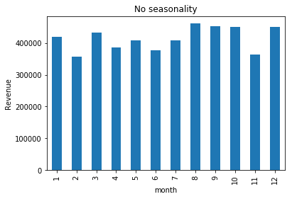

```python
df.groupby('month').PricePerOrder.sum().plot.bar()
plt.title('No seasonality')
plt.ylabel('Revenue')
plt.show()
```

There is no seasonality the revenue. Not in the profit either.

```python
# group by year, but exclude 2011 and 2016 as these are not whole years
df_by_wholeyears = df.loc[df.year.isin([2012, 2013, 2014, 2015])].groupby('year')
```

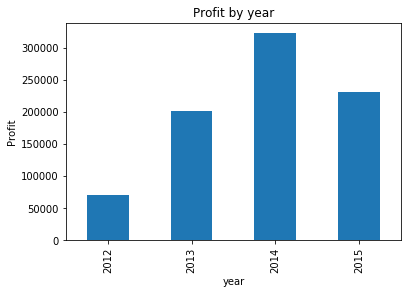

```python
df_by_wholeyears.ProfitPerOrder.sum().plot.bar()
plt.title('Profit by year')
plt.ylabel('Profit')
plt.show()
# Note the entire 2011 or 2016 is not here, so it only makes sense to see 2012:2015
```

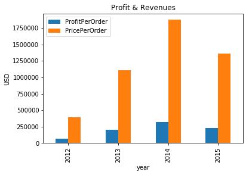

```python
df_by_wholeyears[['ProfitPerOrder', 'PricePerOrder']].sum().plot.bar()
plt.title('Profit & Revenues')
plt.ylabel('USD')
plt.show()
# Note the entire 2011 or 2016 is not here, so it only makes sense to see 2012:2015
```

### popular products

which are ordered the most? which are the most profitable?

```python
df.CategoryName.nunique()
```

```
8
```

```python
df.ProductName.nunique()
```

```
77
```

```python
df_prod = df.groupby(['CategoryName', 'ProductName'])
```

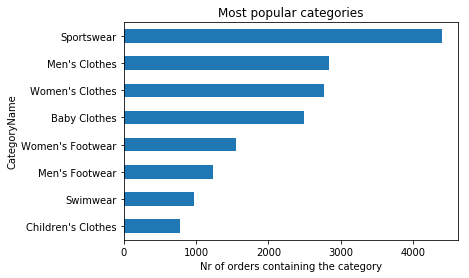

```python
df.groupby('CategoryName').size().sort_values().plot.barh()
plt.title('Most popular categories')
plt.xlabel('Nr of orders containing the category')
plt.show()
```

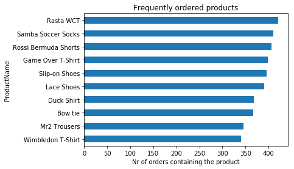

```python
df.groupby('ProductName').size().sort_values().tail(10).plot.barh()
plt.title('Frequently ordered products')
plt.xlabel('Nr of orders containing the product')
plt.show()
```

The graphs above does not take into account the fact that some products are sold in larger quantities, i.e. it only counts the occurence.

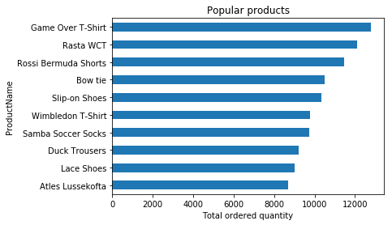

```python
df.groupby('ProductName')['Quantity'].sum().sort_values().tail(10).plot.barh()
plt.title('Popular products')
plt.xlabel('Total ordered quantity')
plt.show()
```

## profitable products

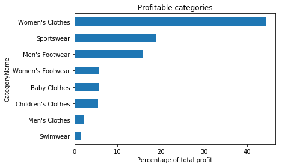

```python
profits_bycategory = df.groupby('CategoryName')['ProfitPerOrder'].sum().sort_values() / profit*100
profits_bycategory.plot.barh()
plt.title('Profitable categories')
plt.xlabel('Percentage of total profit')
plt.show()
```

Women's clothes is the most profiable. Should we stop selling the other categories? It turns out, diving one level of specificity deeper (namely into `ProductName`) yields more insights, due to the fact that only a few products contribute to the bottom line.

```python
print("The single most profitable product stands for ",
      np.round(df.groupby('ProductName')['ProfitPerOrder'].sum().max() / profit*100),
      "% of the total profits")
```

```
The single most profitable product stands for  36.0 % of the total profits
```

```python
print("Five most profitable products and their % contributed profit:")
df.groupby('ProductName')['ProfitPerOrder'].sum().sort_values(ascending=False).head() / profit*100
```

```
Five most profitable products and their % contributed profit:
```

```
ProductName
Halter Dress       36.068853
Davenport Shoes    14.593056
Tennis Suit         5.378772
RDL Suit            5.263586
WFS Shoes           3.333439
Name: ProfitPerOrder, dtype: float64
```

```python
top2products = df.groupby('ProductName')['ProfitPerOrder'].sum().sort_values(ascending=False).head(2)
top2products = top2products.index.tolist()
top2products
```

```
['Halter Dress', 'Davenport Shoes']
```

## deep dive into the top 2 products

since the top 2 products stand for over half the profits, it is reasonable to analyze these two further and create some insights.

who are the shippers?

have we had discounts on these, if so did it correlate with higher sales?

when during the year are these products ordered the most? maybe we can increase the advertising during this period to make our cash cows even better!

cross selling: what is the top2 product frequently bought *together with*? If the dress is often accompanyed by a belt, we should have a recommendation page when someone buys it. Or maybe offer a discount if (and only if) the buyer did not add that belt themselves to the cart. Machine learning can be used here, in particular Association rule learning https://en.wikipedia.org/wiki/Association_rule_learning, preferably the a-priori algorithm https://en.wikipedia.org/wiki/Apriori_algorithm which is implemented in R https://cran.r-project.org/web/packages/arules/index.html We will do this if there is time.

Are they ever out of stock? They should not be. If they are out of stock, during what periods are they? The column `UnitsInStock` will be useful.

```python
top2products
```

```
['Halter Dress', 'Davenport Shoes']
```

```python
# select cols
cols_4 = ['OrderID', 'ProductName',
          'PricePerOrder', 'ProfitPerOrder', 'Quantity', 'Discount',
          'OrderDate', 'year', 'month', 'yearmonth']

# fiter out rows for the top2 products
df2 = df.loc[df.ProductName.isin(top2products), cols_4]
```

```python
# set date as index
# df2 = df2.set_index('OrderDate')
```

```python
df2 = df2.sort_values('yearmonth')
```